# Inner Products and Orthogonality

This is a summary of key topics in inner products and orthogonality. The content is based on Math 108B taught by Professor Karel Casteels in Summer 2022.

# Inner Products

Let $V$ be a vector space over $\mathbb{F}$. For our purposes, $\mathbb{F}$ will always be $\mathbb{R}$ or $\mathbb{C}$. Roughly, an inner product on $V$ over $\mathbb{F}$ is just a generalization of the dot product on $\mathbb{R}^n$ or $\mathbb{C}^n$. Recall:

- In $\mathbb{R}^n$, $\vec{v}\cdot\vec{w}=v_1w_1+v_2w_2+\dots+v_nw_n=\vec{v}^T\vec{w}$.
- In $\mathbb{C}^n$, $\vec{v}\cdot\vec{w}=v_1\bar{w_1}+v_2\bar{w_2}+\dots+v_n\bar{w_n}$

There are called the **standard inner products** on $\mathbb{R}^n$ or $\mathbb{C}^n$.

## Formal Definition

Let $V$ be a vector space over $\mathbb{R}$ or $\mathbb{C}$. An inner product on $V$ is a function $\left<,\right>:V\times V\to\mathbb{F}$ such that

1. **Linearity in the First Argument:** $\left<\vec{v}+\vec{w},\vec{u}\right>=\left<\vec{v},\vec{u}\right>+\left<\vec{w},\vec{u}\right> \forall \vec{u}, \vec{v},\vec{w}\in V$.
2. **Homogeneity in the First Argument:** $\left<c\vec{v},\vec{w}\right>=c\cdot\left<\vec{v},\vec{w}\right> \forall c\in\mathbb{F}, \forall \vec{v},\vec{w} \in \mathbb{F}$
3. **Conjugate Symmetry:** $\left<\vec{v},\vec{w}\right>=\overline{\left<\vec{w},\vec{v}\right>} \forall \vec{v},\vec{w}\in V$. Note that **symmetry** holds in $\mathbb{R}$, $\left<\vec{v},\vec{w}\right>=\left<\vec{w},\vec{v}\right>$
4. **Positive Definiteness:** $\forall\vec{v}\in V, \left<\vec{v},\vec{v}\right>\geq 0$, which implies $\left<\vec{v},\vec{v}\right>=0\iff \vec{v}=0$

## Important Properties

1. $\left<\vec{v},\vec{w}+\vec{u}\right> = \left<\vec{v},\vec{w}\right>+\left<\vec{v},\vec{u}\right>$
2. $\left<\vec{v},c\vec{w}\right> = \bar{c}\left<\vec{v},\vec{w}\right>$
3. $\left<\vec{v},\vec{0}\right>=\left<\vec{0},\vec{v}\right>=0$
4. If $\left<\vec{v},\vec{w}\right>=\left<\vec{v},\vec{y}\right>$ for all $\vec{v}$, then $\vec{w}=\vec{y}$

## Normal/Length

The **length** or **norm** of $\vec{v}$ is defined to be \begin{equation*} ||\vec{v}||=\sqrt{\left<\vec{v},\vec{v}\right>} \end{equation*}

- For example, with dot products on $\mathbb{R}^n$, \begin{equation*} \begin{Vmatrix} x_1 \\ x_2 \\ \vdots \\ x_n \end{Vmatrix}=\sqrt{x^2_1+x^2_2+\dots+x^2_n} \end{equation*}
- Note that $||\vec{v}||^2=\left<\vec{v},\vec{v}\right>$
- A vector $\vec{v}$ is a unit vector if $$||\vec{v}||=1\iff ||\vec{v}||^2=1$$ If $\vec{v}\neq 0$, we can normalize $\vec{v}$ by dividing its own norm.

## Important Properties

1. $||c\vec{v}||=|c|\cdot||\vec{v}||$
2. **Restatement of the axiom:** $||\vec{v}||=0\iff \vec{v}=0$
3. **Cauchy-Schwartz inequality:** $|\left<\vec{v},\vec{w}\right>|\leq ||\vec{v}||\cdot||\vec{w}||$
4. **Triangle Inequality:** $||\vec{v}+\vec{w}||\leq ||\vec{v}||+||\vec{w}||$

# Orthogonality

In an inner product space $V$, two vectors $\vec{v},\vec{w}$ are orthogonal (or geometrically speaking, perpendicular) if $$\left<\vec{v},\vec{w}\right>=0$$.

Suppose $\vec{v},\vec{w}$ are two non-zero vectors in $V$. We want to find a new vector $\vec{v}'$ such that it is orthogonal to $\vec{w}$. i.e. $\left<\vec{v}',\vec{w}\right>=0$. Suppose we are in $\mathbb{R}^2$. Consider a new vector $c\vec{w}$ such that $\vec{v}'=\vec{v}-c\vec{w}$ is orthogonal to $\vec{w}$. We want to find $c$. \begin{align*} (\vec{v}-c\vec{w})\cdot\vec{w}&=0\\ \vec{v}\cdot\vec{w}-c\vec{w}\cdot\vec{w}&=0\\ c&=\frac{\vec{v}\cdot\vec{w}}{\vec{w}\cdot\vec{w}} \end{align*}

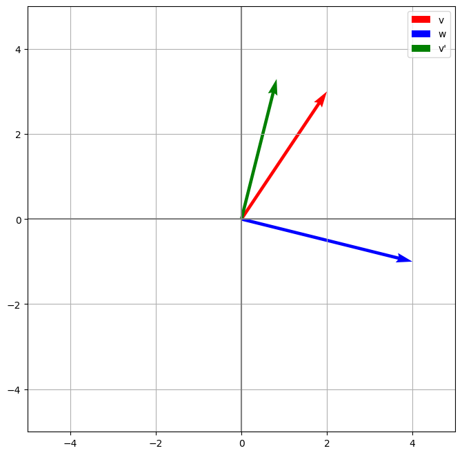

```python
import numpy as np
import matplotlib.pyplot as plt

# Define vectors v and w
v = np.array([2, 3])
w = np.array([4, -1])

# Compute v' that is perpendicular to w
c = np.dot(v,w)/np.dot(w,w)
v_prime = v - c * w

# Plotting
plt.figure(figsize=(8, 8))
plt.quiver(0, 0, v[0], v[1], angles='xy', scale_units='xy', scale=1, color='r', label='v')
plt.quiver(0, 0, w[0], w[1], angles='xy', scale_units='xy', scale=1, color='b', label='w')
plt.quiver(0, 0, v_prime[0], v_prime[1], angles='xy', scale_units='xy', scale=1, color='g', label="v'")

# Setting the limits and labels
plt.xlim(-5, 5)
plt.ylim(-5, 5)
plt.axvline(x=0, color='grey')
plt.axhline(y=0, color='grey')
plt.grid(True)
plt.legend()
plt.show()
```

To generalize, we can take $\vec{v}'=\vec{v}-\frac{\left<\vec{v},\vec{w}\right>}{\left<\vec{w},\vec{w}\right>}\cdot\vec{w}$. And we now we verify \begin{equation*} \left<\vec{v}-\frac{\left<\vec{v},\vec{w}\right>}{\left<\vec{w},\vec{w}\right>},\vec{w}\right>=\left<\vec{v},\vec{w}\right>-\frac{\left<\vec{v},\vec{w}\right>}{\left<\vec{w},\vec{w}\right>}\left<\vec{w},\vec{w}\right>=0 \end{equation*}

# Orthogonal/Orthonormal Sets

- A set $S\subseteq V\backslash\{\vec{0}\}$ is **orthogonal** if $$\left<\vec{v},\vec{w}\right>=0$$ For all $\vec{v},\vec{w}\in S$.
- A set $S\subseteq V\backslash\{\vec{0}\}$ is **orthonormal** if \begin{equation*} \left<\vec{v},\vec{w}\right>= \begin{cases} 1 & \text{if } \vec{v}=\vec{w}\\ 0 & \text{if } \vec{v}\neq \vec{w} \end{cases} \end{equation*}
- Note that an orthogonal set $S$ can be turned into an orthonormal set by replacing $\vec{v}$ with $\frac{\vec{v}}{||\vec{v}||}$ for all $\vec{v}\in V$.
- Having an orthogonal basis (or better orthonormal) is helpful for calculations. Suppose $(\vec{w_1},\vec{w_2},\dots,\vec{w_n})$ is an orthogonal basis and we want, for a given $\vec{v}\in V$, to write $\vec{v}=c_1\vec{v_1}+\dots+c_n\vec{v_n}$. Then to find $c_1$, consider \begin{align*} \left<\vec{v},\vec{w_1}\right>&=\left<c_1\vec{w_1}+\dots+c_n\vec{w_n},\vec{w_1}\right>\\ &=c_1\left<\vec{w_1},\vec{w_1}\right>+c_2\left<\vec{w_2},\vec{w_1}\right>+\dots+c_n\left<\vec{w_n},\vec{w_1}\right>\\ &=c_1\left<\vec{w_1},\vec{w_1}\right> \end{align*}Therefore, \begin{equation*} c_1=\frac{\left<\vec{v},\vec{w_1}\right>}{\left<\vec{w_1},\vec{w_1}\right>} \end{equation*}If $\beta$ is orthogonal, then $c_1=\left<\vec{v},\vec{w_1}\right>$. Similarly, $c_i=\frac{\left<\vec{v},\vec{w_i}\right>}{\left<\vec{w_i},\vec{w_i}\right>}$. If $\beta$ is orthonormal, then $c_i=\left<\vec{v},\vec{w_i}\right>$
- To compute $||\vec{v}||$, we consider $||\vec{v}||^2$. \begin{align*} ||\vec{v}||^2&=\left<\vec{v},\vec{v}\right>\\ &=\left<c_1\vec{w_1}+\dots+c_n\vec{w_n},c_1\vec{w_1}+\dots+c_n\vec{w_n}\right> \\ &=c_1\bar{c_1}\left<\vec{w_1},\vec{w_1}\right>+c_1\bar{c_2}\left<\vec{w_1},\vec{w_2}\right>+\dots+c_1\bar{c_n}\left<\vec{w_1},\vec{w_n}\right>+c_2\bar{c_1}\left<\vec{w_2},\vec{w_1}\right>+c_2\bar{c_2}\left<\vec{w_2},\vec{w_2}\right>+\dots\\ &=c_1\bar{c_1}\left<\vec{w_1},\vec{w_1}\right>+\dots+c_n\bar{c_n}\left<\vec{w_n},\vec{w_n}\right>\\ &=|c_1|^2||\vec{w_1}||^2+|c_2|^2||\vec{w_2}||^2+\dots+|c_n|^2||\vec{w_n}||^2 \end{align*}If $\beta$ is orthonormal, then $||w_i||^2=1, \forall i$ and $||\vec{v}||^2=|c_1|^2+|c_2|^2+\dots+|c_n|^2$. Relate this to the Pythagorean Theorem!
- In fact, all finite dimensional inner product spaces have an orthogonal basis.
- If $S$ is an orthogonal set in $V$, then $S$ is linearly independent.

# Gram-Schmidt Process

This process can transform a basis of $V$ into an orthogonal basis of $V$. We start with a linearly independent set $(\vec{v_1},\vec{v_2},\dots,\vec{v_n})$. The Gram-Schmidt process will output $(\vec{w_1},\vec{w_2},\dots,\vec{w_n})$, which is an orthogonal set with the same span: $\text{Span}(\vec{v_1},\vec{v_2},\dots,\vec{v_n})=\text{Span}(\vec{w_1},\vec{w_2},\dots,\vec{w_n})$. The steps are as follows:

- **Step 1:** Set $\vec{w_1}=\vec{v_1}$.
- **Step i:** Assuming we have constructed $\vec{w_1},\dots,\vec{w_{i-1}}$ with $\text{Span}(\vec{v_1},\vec{v_2},\dots,\vec{v_{i-1}})=\text{Span}(\vec{w_1},\vec{w_2},\dots,\vec{w_{i-1}})$. Then, \begin{equation*} \vec{w_i}=\vec{v_i}-\frac{\left<\vec{v_i},\vec{w_1}\right>}{\left<\vec{w_1},\vec{w_1}\right>}\vec{w_1}-\frac{\left<\vec{v_i},\vec{w_2}\right>}{\left<\vec{w_2},\vec{w_2}\right>}\vec{w_2}-\dots-\frac{\left<\vec{v_i},\vec{w_{i-1}}\right>}{\left<\vec{w_{i-1}},\vec{w_{i-1}}\right>}\vec{w_1}=\vec{v_i}-\sum_{h=1}^{i-1} \frac{\left<\vec{v_i},\vec{w_h}\right>}{\left<\vec{w_h},\vec{w_h}\right>}\vec{w_h} \end{equation*}

## Example

Let $V=P_2(\mathbb{R})$,$$\left<p,q\right>=\int_{-1}^1 p(t)q(t)dt,$$ with basis $$\beta=(\vec{v_1},\vec{v_2},\vec{v_3})=(1,x,x^2)$$. Find an orthogonal basis with the same span as the original basis.

1. Step 1: Set $$\vec{w_1}=\vec{v_1}=1, ||\vec{w_1}||^2=2$$
2. Step 2: $$\vec{w_2}=\vec{v_2}-\frac{\left<\vec{v_w},\vec{w_1}\right>}{\left<\vec{w_1},\vec{w_1}\right>}\vec{w_1}=x-\frac{0}{2}\cdot 1=x, ||\vec{w_2}||^2=\frac{2}{3}$$
3. Step 3: $$\vec{w_3}=\vec{v_3}-\frac{\left<\vec{v_3},\vec{w_1}\right>}{\left<\vec{w_1},\vec{w_1}\right>}\vec{w_1}-\frac{\left<\vec{v_3},\vec{w_2}\right>}{\left<\vec{w_2},\vec{w_2}\right>}\vec{w_2}=x^2-\frac{\frac{2}{3}}{2}\cdot 1-0x=x^2-\frac{1}{3}, ||\vec{w_3}||^2=\frac{8}{45}$$ Therefore, an orthogonal basis for $P_2(\mathbb{R})$ with respect to this inner product is $(1,x,x^2-\frac{1}{3})$. Furthermore, an orthonormal basis is $(\frac{1}{\sqrt{2}}, \sqrt{\frac{2}{3}}x, \sqrt{\frac{45}{8}}(x^2-\frac{1}{3}))$.

## Python Example for Vectors in $\mathbb{R}^3$

```python
import numpy as np

# Define three non-orthogonal vectors in R^3
v_1 = np.array([1, 1, 1])
v_2 = np.array([1, 2, 3])
v_3 = np.array([2, 1, 3])
original_basis = np.array([v_1,v_2,v_3])

# Step-by-Step Computation
# w_1 = v_1
# w_2 = v_2 - np.dot(v_2,w_1)/np.dot(w_1,w_1) * w_1
# w_3 = v_3 - np.dot(v_3,w_1)/np.dot(w_1,w_1) * w_1 - np.dot(v_3,w_2)/np.dot(w_2,w_2) * w_2

# We will generalize by using a Python function
def gram_schmidt(vectors):
    orthogonal_basis = []
    for v in vectors:
        for u in orthogonal_basis:
            proj = np.dot(v, u) / np.dot(u, u) * u
            v = v - proj
        orthogonal_basis.append(v)

    orthonormal_basis = [vec/np.linalg.norm(vec) for vec in orthogonal_basis]
    return orthogonal_basis, orthonormal_basis

orthogonal_basis, orthonormal_basis = gram_schmidt([v_1, v_2, v_3])

print("Original basis:")
for vec in original_basis:
    print(vec)

print("\nOrthogonal basis:")
for vec in orthogonal_basis:
    print(vec)

print("\nOrthonormal basis:")
for vec in orthonormal_basis:
    print(vec)
```

```
Original basis:
[1 1 1]
[1 2 3]
[2 1 3]

Orthogonal basis:
[1 1 1]
[-1.  0.  1.]
[ 0.5 -1.   0.5]

Orthonormal basis:
[0.57735027 0.57735027 0.57735027]
[-0.70710678  0.          0.70710678]
[ 0.40824829 -0.81649658  0.40824829]
```

## Orthogonal Complement

Let $V$ be an inner product space and let $S$ be an nonempty subset of $V$. The **orthogonal complement** of $S$ is the set $S^{\perp}=\{\vec{v}\in V: \left<\vec{v},\vec{s}\right>=0, \forall \vec{s}\in S\}$.

- $\{\vec{0}\}^{\perp}=V, V^\perp=\{\vec{0}\}$. Since if $\vec{v}\in V^\perp$, then $\left<\vec{v},\vec{s}\right>=0, \forall\vec{s}\in V$.
- Consider the example from above: $V=P_2(\mathbb{R}),$ $$\left<f(x),g(x)\right>=\int_{-1}^1 f(x)g(x)dx.$$ Let $S=\{x\}$. Then $S^\perp=\text{Span}(1,x^2)$.
- In general, $S^\perp$ is a subspace (regardless of whether $S$ is a subspace or not).
- If $V$ is finite dimensional and $W$ is a subspace, then $V=W\bigoplus W^\perp$. i.e. every $\vec{v}\in V$ can be uniquely expressed as $\vec{v}+\vec{w}+\vec{u}$ for $\vec{w}\in W, \vec{u}\in W^\perp$.

Notice that

- If $(\vec{w_1},\dots,\vec{w_k})$ is an orthogonal basis for $W$, then we can extend this basis $(\vec{w_1},\dots,\vec{w_k},\vec{w_{k+1}},\dots,\vec{w_n})$ of $V$. Apply Gram-Schmidt to get $(\vec{w_1}',\dots,\vec{w_k}',\vec{w_{k+1}}',\dots,\vec{w_n}')$ as an orthogonal basis for $V$, and $(\vec{w_{k+1}}',\dots,\vec{w_n}')$ will be an orthogonal basis for $W^\perp$.
- $\text{Dim}(V)=\text{Dim}(W)+\text{Dim}(W^\perp)$
- Pythagorean Theorem: If $\vec{w}\in W, \vec{u}\in W^\perp$, then $||\vec{w}+\vec{u}||^2=||\vec{w}||^2+||\vec{u}||^2$.
- Let $V=W\bigoplus W^\perp$. If $\vec{v}=\vec{w}+\vec{u}, \vec{w}\in W, \vec{u}\in W^\perp$, then $\vec{w}$ minimizes $||\vec{v}-\vec{w}'||$ over all $\vec{w}'\in W$. In other words, $||\vec{v}-\vec{w}||\leq ||\vec{v}-\vec{w}'||, \forall \vec{w}'\in W$.